# MPI Stats with R

Emily Davenport

1/21/2019

## Welcome - outline

Welcome to the Intro Statistics with R workshop. Our goal is to give you a crash course introduction into how to do basic statistics in the free and widely used statistical programming language R.

On Day 1, we will focus on learning R. The learning objectives for today are:

- Assign variables
- Read data into and out of R
- Learn data types
- Learn to subset data
- Calculate basic statistics on data
- Create our own functions
- Make some plots
- Load a library

Today we’ll be working with a data set of [ecological survey](https://figshare.com/articles/Portal_Project_Teaching_Database/1314459) data that have been pruned a bit. It consists of actual biological data collected over time in the Chihuahuan Desert in Arizona.

## RStudio

We will use R via the interactive development environment (IDE) RStudio. In this lesson we’ll explore some of its useful features.

[figure not shown]

RStudio IDE

### The different panels

First, let’s open a new R script in the text editor (“File” -> “New File” -> “R Script”). One of the biggest advantages of using RStudio is how easy it makes to test new code your write. Let’s write a few lines of code in the text editor.

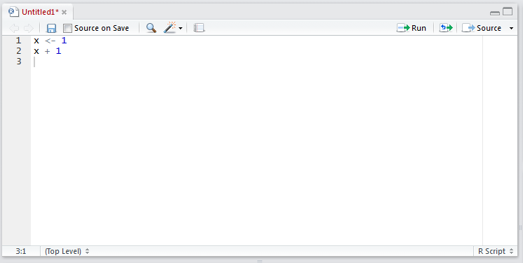

RStudio editor

By clicking on the button that says “Run”, we can send a line from the script to the Console to be executed. If we highlight multiple lines of code, all these lines will be run in the Console. As a shortcut, you can press “Ctrl-Enter” instead of clicking on the “Run” button.

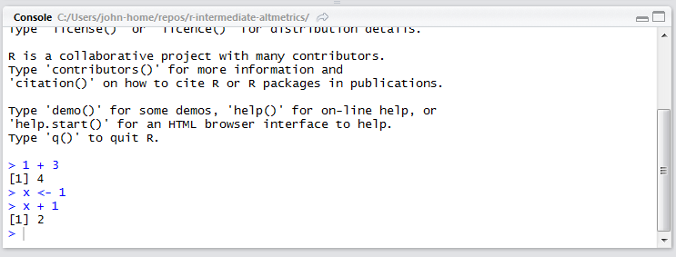

RStudio Console

Using the up and down arrows you to browse through past commands.

The Environment panel describes all the objects present in the R session.

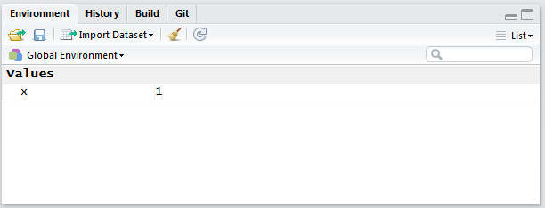

RStudio Environment

The History panel displays all the past commands that were run in the Console. These past commands can be selected and then sent either to the script (“Source”) or to the Console to be run again.

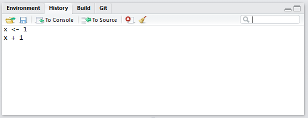

RStudio History

The Files panel shows all the available files available in the current working directory.

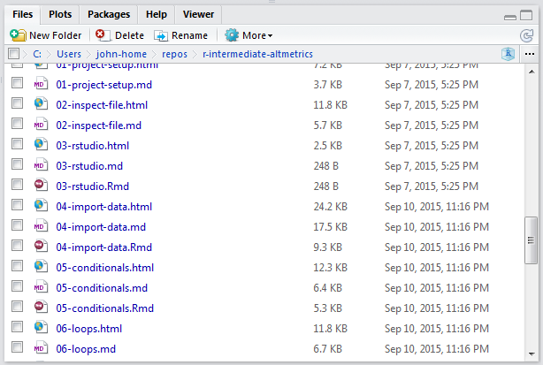

RStudio Files

The Help panel shows the documentation for R functions. We can either run `?` in front of the function name to bring up the documentation, e.g. `?sum`. Alternatively, we can put the cursor on the name of the function and press the F1 key.

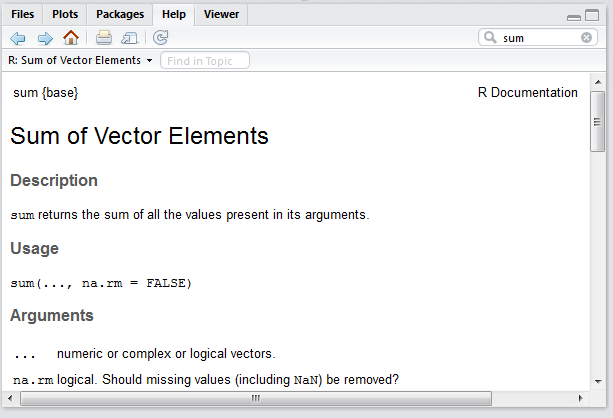

RStudio Help

Lastly the Plots panel will display any graphs we create and the Packages panel shows which packages have been installed.

## Assign variables

You can get output from R simply by typing math in the console:

```r
3 + 5
```

```
## [1] 8
```

```r
12 / 7
```

```
## [1] 1.714286
```

However, to do useful and interesting things, we need to assign *values* to *objects*. To create an object, we need to give it a name followed by the assignment operator `<-`, and the value we want to give it:

```r
weight_kg <- 55
```

`<-` is the assignment operator. It assigns values on the right to objects on the left. So, after executing `x <- 3`, the value of `x` is `3`. The arrow can be read as 3 **goes into** `x`. For historical reasons, you can also use `=` for assignments, but not in every context. Because of the [slight](http://blog.revolutionanalytics.com/2008/12/use-equals-or-arrow-for-assignment.html) [differences](http://r.789695.n4.nabble.com/Is-there-any-difference-between-and-tp878594p878598.html) in syntax, it is good practice to always use `<-` for assignments.

In RStudio, typing `Alt` + `-` (push `Alt` at the same time as the `-` key) will write `<-` in a single keystroke in a PC, while typing `Option` + `-` (push `Option` at the same time as the `-` key) does the same in a Mac.

Objects can be given any name such as `x`, `current_temperature`, or `subject_id`. You want your object names to be explicit and not too long. They cannot start with a number (`2x` is not valid, but `x2` is). R is case sensitive (e.g., `weight_kg` is different from `Weight_kg`). There are some names that cannot be used because they are the names of fundamental functions in R (e.g., `if`, `else`, `for`, see [here](https://stat.ethz.ch/R-manual/R-devel/library/base/html/Reserved.html) for a complete list). In general, even if it’s allowed, it’s best to not use other function names (e.g., `c`, `T`, `mean`, `data`, `df`, `weights`). If in doubt, check the help to see if the name is already in use.

Now that R has `weight_kg` in memory, we can do arithmetic with it. For instance, we may want to convert this weight into pounds (weight in pounds is 2.2 times the weight in kg):

```r
2.2 * weight_kg
```

```
## [1] 121
```

We can also change an object’s value by assigning it a new one:

```r
weight_kg <- 57.5
2.2 * weight_kg
```

```
## [1] 126.5
```

This means that assigning a value to one object does not change the values of other objects For example, let’s store the animal’s weight in pounds in a new object, `weight_lb`:

```r
weight_lb <- 2.2 * weight_kg
```

and then change `weight_kg` to 100.

```r
weight_kg <- 100
```

What do you think is the current content of the object `weight_lb`? 126.5 or 220?

### Comments

The comment character in R is `#`, anything to the right of a `#` in a script will be ignored by R. It is useful to leave notes, and explanations in your scripts. RStudio makes it easy to comment or uncomment a paragraph: after selecting the lines you want to comment, press at the same time on your keyboard `Ctrl` + `Shift` + `C`. If you only want to comment out one line, you can put the cursor at any location of that line (i.e. no need to select the whole line), then press `Ctrl` + `Shift` + `C`.

## Reading data into R

The most common way to read data into R is using the function `read.table`.

Let’s tell R to read in some data we’ve saved as a .csv file using the `read.table` function:

```r
surveys <- read.table("surveys_complete.csv", sep = ",", header = TRUE, stringsAsFactors = FALSE)
```

Three things I often do when first reading in data are:

1. Check the size
2. See what the columns are
3. Look at the first few lines

To find the number of rows and columns, use `dim`. In R, rows are always listed first, and columns listed second.

```r
dim(surveys)
```

```
## [1] 30463    13
```

To see a small overview of the columns, use `str`.

```r
str(surveys)
```

```
## 'data.frame':    30463 obs. of  13 variables:
##  $ record_id      : int  845 1164 1261 1756 1818 1882 2133 2184 2406 3000 ...
##  $ month          : int  5 8 9 4 5 7 10 11 1 5 ...
##  $ day            : int  6 5 4 29 30 4 25 17 16 18 ...
##  $ year           : int  1978 1978 1978 1979 1979 1979 1979 1979 1980 1980 ...
##  $ plot_id        : int  2 2 2 2 2 2 2 2 2 2 ...
##  $ species_id     : chr  "NL" "NL" "NL" "NL" ...
##  $ sex            : chr  "M" "M" "M" "M" ...
##  $ hindfoot_length: int  32 34 32 33 32 32 33 30 33 31 ...
##  $ weight         : int  204 199 197 166 184 206 274 186 184 87 ...
##  $ genus          : chr  "Neotoma" "Neotoma" "Neotoma" "Neotoma" ...
##  $ species        : chr  "albigula" "albigula" "albigula" "albigula" ...
##  $ taxa           : chr  "Rodent" "Rodent" "Rodent" "Rodent" ...
##  $ plot_type      : chr  "Control" "Control" "Control" "Control" ...
```

To see the first few lines of the data set, use `head`

```r
head(surveys)
```

```
##   record_id month day year plot_id species_id sex hindfoot_length weight
## 1       845     5   6 1978       2         NL   M              32    204
## 2      1164     8   5 1978       2         NL   M              34    199
## 3      1261     9   4 1978       2         NL   M              32    197
## 4      1756     4  29 1979       2         NL   M              33    166
## 5      1818     5  30 1979       2         NL   M              32    184
## 6      1882     7   4 1979       2         NL   M              32    206
##     genus  species   taxa plot_type
## 1 Neotoma albigula Rodent   Control
## 2 Neotoma albigula Rodent   Control
## 3 Neotoma albigula Rodent   Control
## 4 Neotoma albigula Rodent   Control
## 5 Neotoma albigula Rodent   Control
## 6 Neotoma albigula Rodent   Control
```

## Data classes and types

We’ve now seen a couple of different data types that you can work with in R. An **atomic vector** is the simplest R **data type** and is a linear vector of a single type. `weight_kg` was example if this type. You can add more elements to this vector by using `c()`. For example, say we had a second weight (52.3kg) that we wanted to record:

```r
weight_kg <- c(weight_kg, 52.3)
weight_kg
```

```
## [1] 100.0  52.3
```

The values stored in weight_kg are `"numeric"`. Other data types are:

- `"logical"` for `TRUE` and `FALSE` (the boolean data type)
- `"integer"` for integer numbers (e.g., 1, 2, 3)
- `"character"` for any text (e.g. “cat”, “dog”, “wombat”)
- `"factor"` for any value you wish to be treated as a grouping variable (e.g. case, control)

Vectors are one of the many **data structures** that R uses. Other important ones are lists (`list`), matrices (`matrix`), and data frames (`data.frame`).

The data we read in earlier is saved as a `data.frame`. We can test that using the function `class()`

```r
class(surveys)
```

```
## [1] "data.frame"
```

The `str` function displays the class information for each column of our data.frame:

```r
str(surveys)
```

```
## 'data.frame':    30463 obs. of  13 variables:
##  $ record_id      : int  845 1164 1261 1756 1818 1882 2133 2184 2406 3000 ...
##  $ month          : int  5 8 9 4 5 7 10 11 1 5 ...
##  $ day            : int  6 5 4 29 30 4 25 17 16 18 ...
##  $ year           : int  1978 1978 1978 1979 1979 1979 1979 1979 1980 1980 ...
##  $ plot_id        : int  2 2 2 2 2 2 2 2 2 2 ...
##  $ species_id     : chr  "NL" "NL" "NL" "NL" ...
##  $ sex            : chr  "M" "M" "M" "M" ...
##  $ hindfoot_length: int  32 34 32 33 32 32 33 30 33 31 ...
##  $ weight         : int  204 199 197 166 184 206 274 186 184 87 ...
##  $ genus          : chr  "Neotoma" "Neotoma" "Neotoma" "Neotoma" ...
##  $ species        : chr  "albigula" "albigula" "albigula" "albigula" ...
##  $ taxa           : chr  "Rodent" "Rodent" "Rodent" "Rodent" ...
##  $ plot_type      : chr  "Control" "Control" "Control" "Control" ...
```

We can see that `surveys` has two classes of data: `int`, which stands for “integers” and `chr` which stands for “character.”

## Subsetting data

There are a few ways to pull out specific values of our data. If we have a vector and we wish to look at the first entry, you type the name of the vector and the number 1 in brackets:

```r
weight_kg[1]
```

```
## [1] 100
```

If we want to look at the second value, type 2 in brackets:

```r
weight_kg[2]
```

```
## [1] 52.3
```

For 2-dimensional data types, you’ll type the number of the row, comma, the number of the column you wish to reference. For example, let’s look at the value in the second row, third column in surveys:

```r
surveys[2, 3]
```

```
## [1] 5
```

Let’s look at the first row, fifth column:

```r
surveys[1, 5]
```

```
## [1] 2
```

You can look at entire row by reference the number of that row and leaving the column position blank. Let’s look at all of the first row of `surveys`:

```r
surveys[1, ]
```

```
##   record_id month day year plot_id species_id sex hindfoot_length weight
## 1       845     5   6 1978       2         NL   M              32    204
##     genus  species   taxa plot_type
## 1 Neotoma albigula Rodent   Control
```

To reference the `hindfoot_length` column, which is the 8th column, we can type:

```r
surveys[ ,8]
```

[Note: the above code should output 30,000 values of hindfoot length to your R terminal, but I’ve hidden them here.]

You can also reference columns of a dataframe by the name of the column. Let’s look at all of the `hindfoot_length` values in `surveys`:

```r
surveys$hindfoot_length
```

[Note: the above code should output 30,000 values of hindfoot length to your R terminal, but I’ve hidden them here.]

Let’s say we want to only look at the first five values of `hindfoot_length`. To do that, we can “slice” the data where we put the number of the element we want to start on, `:`, the number of the element we want to end on. To get the first five values of `hindfoot_length`:

```r
surveys$hindfoot_length[1:5]
```

```
## [1] 32 34 32 33 32
```

We can also look at multiple elements of `hindfoot_length` that aren’t all next to each other by indexing using the `c()` function. Let’s look at at the 1, 4, 5, and 7th elements of `hindfoot_length`:

```r
surveys$hindfoot_length[c(1, 4, 5, 7)]
```

```
## [1] 32 33 32 33
```

## Calculating basic statistics on data

R is a statistical language with many useful statistics functions available. Let’s calculate some basic statistics on `hindfoot_length`.

What is the mean value of `hindfoot_length`?

```r
mean(surveys$hindfoot_length)
```

```
## [1] 29.26711
```

Let’s calculate the median value of `hindfoot_length`:

```r
median(surveys$hindfoot_length)
```

```
## [1] 32
```

Let’s calculate the standard deviation of `hindfoot_length`:

```r
sd(surveys$hindfoot_length)
```

```
## [1] 9.540448
```

Often it’s useful to quickly glance at all of these statistics and more for our data. We can use the `summary()` function to find the minimum, 1st quartile, median, mean, 3rd quartile, and maximum value in our data:

```r
summary(surveys$hindfoot_length)
```

```
##    Min. 1st Qu.  Median    Mean 3rd Qu.    Max.
##    2.00   21.00   32.00   29.27   36.00   64.00
```

## Subsetting data that match a pattern with `which`

Sometimes we want to examine only part of our data, based off of one of the variables in our dataset. For example, above we calculated the mean value of `hindfoot_length` using all individuals. We know there are both male and female organisms included in this dataset though, so we may want to calculate mean separately for the two sexes.

How many of each sex are included in the dataset? An easy way to tabulate the number of times each sex is seen in our data is to use the `table` function on the column `sex`:

```r
table(surveys$sex)
```

```
##
##     F     M
## 14466 15997
```

We can see there are ~14k females and ~16k males in our dataset.

The male and female organisms are all mixed together in the data.frame, and we don’t want to go through by hand recording which rows correspond to each sex. We can use R to tell us which rows correspond to “F” vs. “M” records in our data.set. To get a list of indicies of only the female animals (“F” in our dataset), we can use the function `which`. We enter in the vector we want to examine (`surveys$sex`) and ask which elements are equal to the character string we want to find (`"F"`) by using the “is equal to” operator, which is two equal signs in a row (`==`).

```r
female_rows <- which(surveys$sex == "F")
```

If we look at the length of of female_rows using the function `length()`, we see that it’s the same as the value from `table()` above:

```r
length(female_rows)
```

```
## [1] 14466
```

What `female_rows` contains is a vector of the row number for each female record. To take the mean of only the female records for `hindfoot_length`, we index `hindfoot_length` my those female rows and take the mean:

```r
mean(surveys$hindfoot_length[female_rows])
```

```
## [1] 28.79531
```

Challenge: What is the mean `hindfoot_length` in males?

## Saving data

Often we’ll make some calculations on our data and then want to save that data back to our computer for use in other applications or to send to collaborators.

Let’s first make a change to our data and then save it to our computer.

Let’s convert `hindfoot_length` from cm to mm by multiplying by 10.

First, let’s make a new variable that contains the `survey` data.frame.

```r
surveys_new <- surveys
```

Now let’s convert `hindfoot_length` to mm by multiplying by 10, and save back to the `hindfoot_length` in the new `surveys_new` data.frame we made.

```r
surveys_new$hindfoot_length <- surveys_new$hindfoot_length * 10
```

Now if you compare the top few lines of `surveys` and `surveys_new` you can see that `hindfoot_length` is 10x larger in `surveys_new`:

```r
head(surveys)
```

```
##   record_id month day year plot_id species_id sex hindfoot_length weight
## 1       845     5   6 1978       2         NL   M              32    204
## 2      1164     8   5 1978       2         NL   M              34    199
## 3      1261     9   4 1978       2         NL   M              32    197
## 4      1756     4  29 1979       2         NL   M              33    166
## 5      1818     5  30 1979       2         NL   M              32    184
## 6      1882     7   4 1979       2         NL   M              32    206
##     genus  species   taxa plot_type
## 1 Neotoma albigula Rodent   Control
## 2 Neotoma albigula Rodent   Control
## 3 Neotoma albigula Rodent   Control
## 4 Neotoma albigula Rodent   Control
## 5 Neotoma albigula Rodent   Control
## 6 Neotoma albigula Rodent   Control
```

```r
head(surveys_new)
```

```
##   record_id month day year plot_id species_id sex hindfoot_length weight
## 1       845     5   6 1978       2         NL   M             320    204
## 2      1164     8   5 1978       2         NL   M             340    199
## 3      1261     9   4 1978       2         NL   M             320    197
## 4      1756     4  29 1979       2         NL   M             330    166
## 5      1818     5  30 1979       2         NL   M             320    184
## 6      1882     7   4 1979       2         NL   M             320    206
##     genus  species   taxa plot_type
## 1 Neotoma albigula Rodent   Control
## 2 Neotoma albigula Rodent   Control
## 3 Neotoma albigula Rodent   Control
## 4 Neotoma albigula Rodent   Control
## 5 Neotoma albigula Rodent   Control
## 6 Neotoma albigula Rodent   Control
```

Now that we have this updated data, let’s save it to our computer with the file name “surveys_new.csv” using the `write.table()` function.

```r
write.table(surveys_new, "surveys_new.csv", sep = ",", row.names = FALSE, quote = FALSE)
```

Above, we are telling `write.table` to save the variable `surveys_new` to the file `surveys_new.csv`. Each value in a row will be delimited with a comma (`sep = ","`). We don’t want row names saved (since they are just numbers and not informative (`row.names = FALSE`)) and we don’t want R to put quotes around each individual entry (`quote = FALSE`).

If you look at your desktop (or whatever working directory you are currently in your R session), you will see the file “surveys_new.csv”.

## Functions

There are many built in functions in R that we’ve been using (`read.table()`, `mean()`, `sd()`, etc.), but we can also define our own functions. Let’s make our own function called `correcting_function` that will recalibrate a number to be 10% higher than it currently is.

```r
correcting_function <- function(hl) {
  hl*1.1
}
```

We name our function by assigning our `function()` call to a variable (`correcting_function`). Inside the parentheses of `function()` we list the names of the input variables we will use in the body of our function (everything between the {}). In our function, let’s have the user input one variable which in the body we’ll call `hl`, short for hindfoot length.

In the body of the function, we can include as many lines of code as we want. R will return the output of the very last line of code as a default.

Above, the user will enter in a value for `hl`. When the function is run, it runs through the lines of code in the body (so hl * 1.1) and returns the output of the final line.

Let’s try entering in one number (50):

```r
correcting_function(50)
```

```
## [1] 55
```

We can see the output is 55.

How can we run this function on all values of `hindfoot_length`? We can use something called an apply statement. Specifically we’ll use `sapply`. The first argument in `sapply` is the vector you wish to apply your function to and the second argument is the function you wish to use.

Let’s apply the function `correcting_function` to all values of `hindfoot_length` and save it as a new column in our `surveys` data.frame called `hindfoot_length_corrected`:

```r
surveys$hindfoot_length_corrected <- sapply(surveys$hindfoot_length, correcting_function)
head(surveys)
```

```
##   record_id month day year plot_id species_id sex hindfoot_length weight
## 1       845     5   6 1978       2         NL   M              32    204
## 2      1164     8   5 1978       2         NL   M              34    199
## 3      1261     9   4 1978       2         NL   M              32    197
## 4      1756     4  29 1979       2         NL   M              33    166
## 5      1818     5  30 1979       2         NL   M              32    184
## 6      1882     7   4 1979       2         NL   M              32    206
##     genus  species   taxa plot_type hindfoot_length_corrected
## 1 Neotoma albigula Rodent   Control                      35.2
## 2 Neotoma albigula Rodent   Control                      37.4
## 3 Neotoma albigula Rodent   Control                      35.2
## 4 Neotoma albigula Rodent   Control                      36.3
## 5 Neotoma albigula Rodent   Control                      35.2
## 6 Neotoma albigula Rodent   Control                      35.2
```

## Plotting

Another nice feature about R is that there are many functions built in to plot your data. Let’s use some of these functions to quickly look at some of the relationships between the variables in our dataset.

Let’s create a scatterplot to compare `hindfoot_length` with `weight`. The function `plot()` will plot two sets of values against each other along the x and y axis. Let’s have `hindfoot_length` along the x-axis and `weight` along the y-axis:

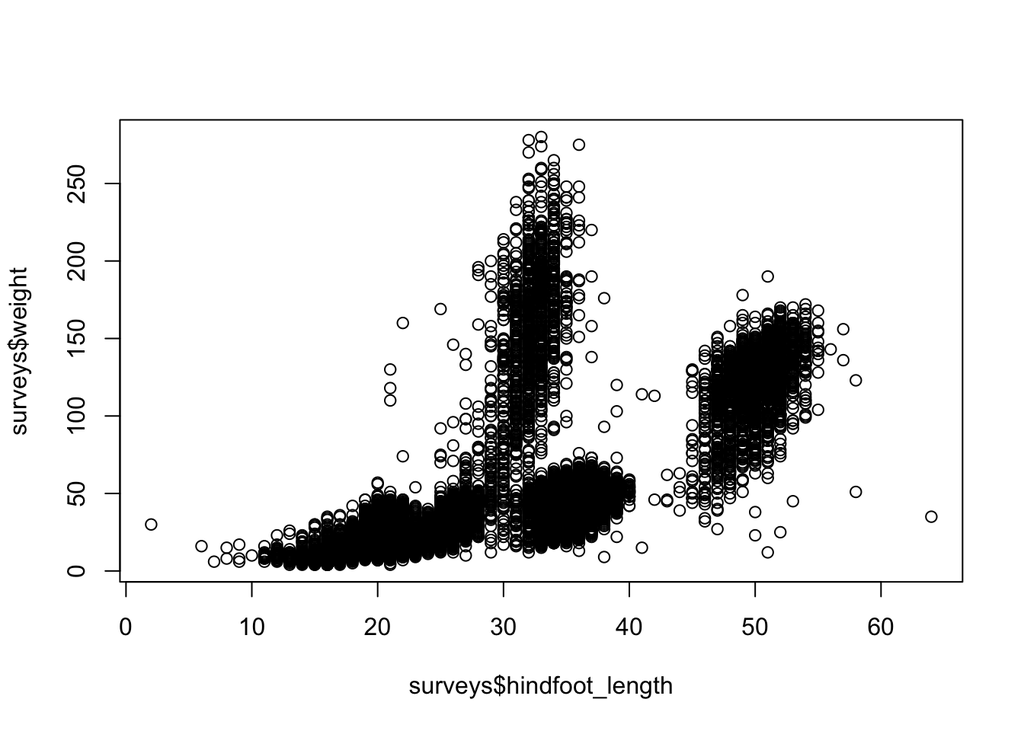

```r
plot(surveys$hindfoot_length, surveys$weight)
```

Let’s look at the help documentation for `plot()` to see how we can make our plot look exactly like we want.

Let’s add more descriptive axis titles, a main title, and color the points blue:

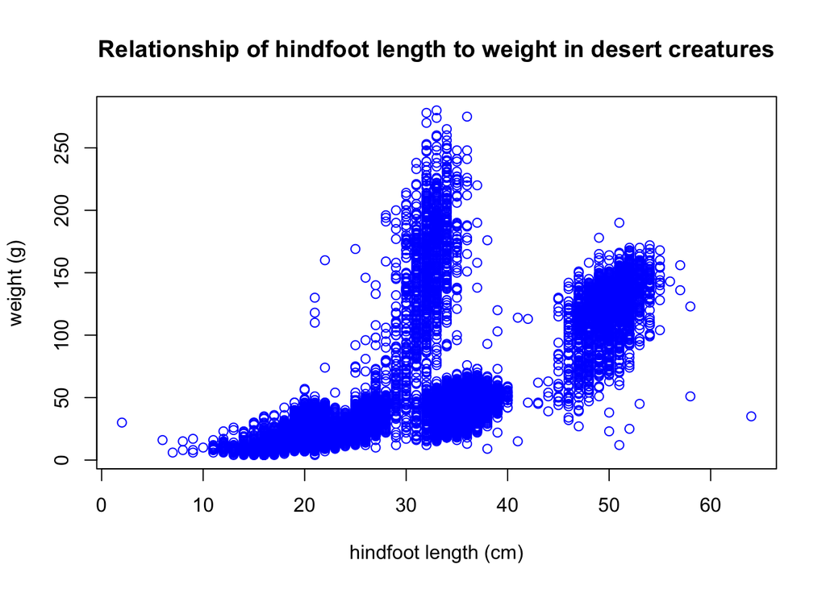

```r
plot(surveys$hindfoot_length, surveys$weight, xlab = "hindfoot length (cm)", ylab = "weight (g)", main = "Relationship of hindfoot length to weight in desert creatures", col = "blue")
```

This plot currently only lives within R. To save it as a file to your computer, you can use the functions `pdf()` to open a connection to a file on your computer, run whatever plotting code you’d like saved, and `dev.off()` to close the connection to that file. Let’s save our scatterplot to our working directory with the title “hindfoot_length_vs_weight_plot.pdf”:

```r
pdf("hindfoot_length_vs_weight_plot.pdf")
plot(surveys$hindfoot_length, surveys$weight, xlab = "hindfoot length (cm)", ylab = "weight (g)", main = "Relationship of hindfoot length to weight in desert creatures", col = "blue")
dev.off()
```

If you look in your current working directory, you’ll now see the file “hindfoot_length_vs_weight_plot.pdf”.

We can also make boxplots easily in R. Let’s make a boxplot of the distribution of `hindfoot_length` by sex:

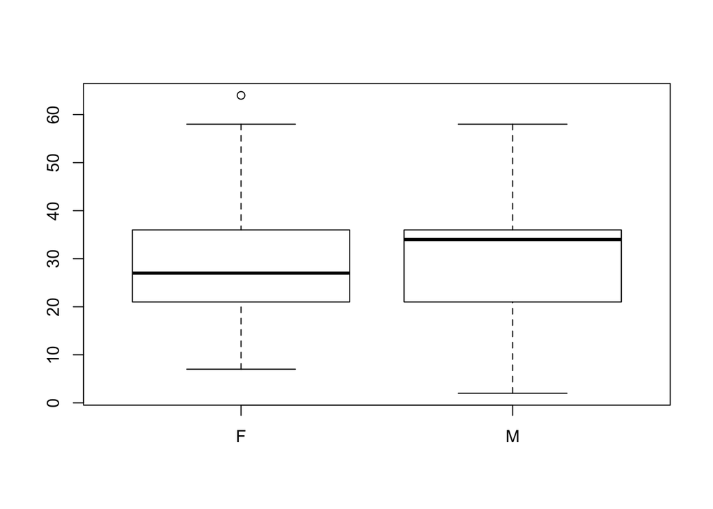

```r
boxplot(surveys$hindfoot_length ~ surveys$sex)
```

Let’s pretty up the plot by including labels and coloring in the boxes.

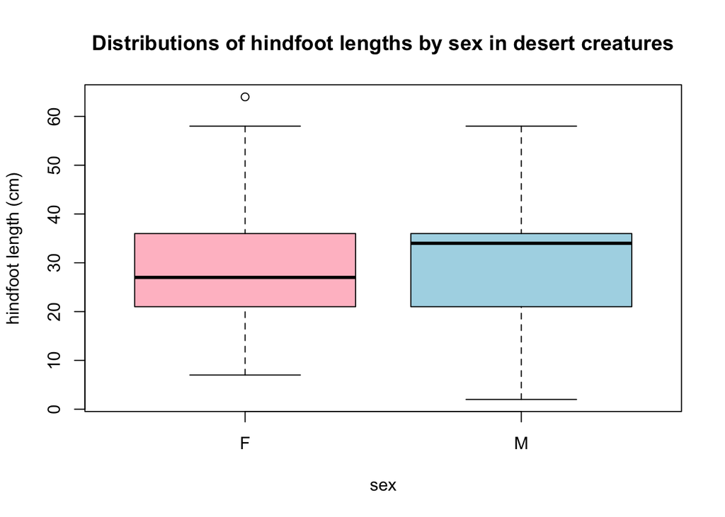

```r
boxplot(surveys$hindfoot_length ~ surveys$sex, xlab = "sex", ylab = "hindfoot length (cm)", main = "Distributions of hindfoot lengths by sex in desert creatures", col = c("pink", "lightblue"))
```

## Loading libraries

R comes with many functions built in (like all of the functions we’ve been using). One of the powerful aspects of R is that anyone can create their own functions and share those with others in bundles called libraries. There is one main location where R libraries are stored, which is called [CRAN](https://cran.r-project.org/) (which stands for the Comprehensive R Archive Network). In RStudio, you can install packages to your local version of R by going over to the “Packages” tab, clicking the “Install” button, and typing in the name of the package you wish install.

Since today was so short, I recommend that you install a [package that will help you keep learning R in R called swirl.](https://swirlstats.com/).

Go over to the Packages tab and click the “Install” button.

[figure not shown]

Packages Install

When the window pops up to install packages, type in the name “swirl”, make sure the “install dependencies” tab is checked, and click “install”.

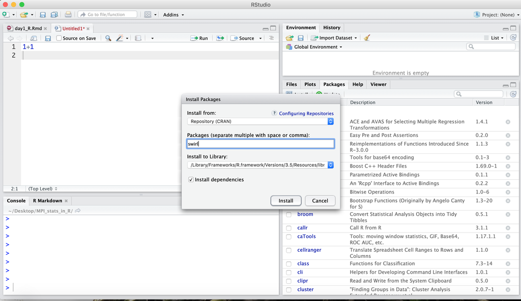

Install Swirl

The code for this package now lives on our computer. However, these functions aren’t automatically loaded into R. You have to tell R which libraries you’d like to open up each time you load R. Let’s tell R to load up the `swirl` package:

```r
library("swirl")
```

You’ll see that this package has a bunch of interactive lessons that you can do right from within R to help learn the language.

There are tons and tons of libraries available for R, to do everything from advanced statistical methods, machine learning, data cleaning, or parallelization. There is a great list of [awesome R packages here](https://awesome-r.com/). Once you get familiar with R, I recommend learning the packages written by Hadley Wickham, including `ggplot2` for plotting, `dplyr` for data munging, and `readr` for reading in large data sets quickly.